# Relatório de Unidade - Autoavaliação UFRPE 2019 (UAG)

# 1 INTRODUÇÃO

Este relatório apresenta as respostas dos discentes, docentes e técnicos da Unidade Acadêmica de Garanhuns (UAG), referente à autoavaliação 2019 da Universidade Federal Rural de Pernambuco (UFRPE), conduzida pela Comissão Própria de Avaliação (CPA). Neste ano foram contemplados dois eixos avaliativos: Planejamento e Avaliação Institucional e Desenvolvimento Institucional.

Esta avaliação foi feita a partir de questionários online, disponibilizados de forma voluntária aos discentes, docentes e técnicos da instituição, no período de 23 de abril a 29 de julho de 2019. Maiores detalhes sobre a metodologia de autoavaliação podem ser encontrados no 2º Relatório Parcial de Autoavaliação Institucional (ANO-BASE 2019), disponível no site da [CPA/UFRPE](http://cpa.ufrpe.br/br/relatorio-de-autoavaliacao-institucional/).

Note que este relatório apresenta os resultados da avaliação da UFRPE *como um todo* sob o ponto de vista dos membros desta unidade; sendo assim, não pode ser interpretado como uma avaliação da unidade propriamente dita.

# 2 PANORAMA

Dentre os membros da comunidade acadêmica desta unidade aptos a participar da avaliação, 18.53% dos estudantes responderam ao questionário (294 de 1587), 57.14% dos docentes responderam ao questionário (104 de 182), e 26.44% dos técnicos responderam ao questionário (23 de 87).

Os gráficos a seguir apresentam os resultados da avaliação de alguns itens pré-selecionados: Ações de Planejamento de Cursos e Utilização dos Resultados da Autoavaliação Institucional no Planejamento de Cursos, além da atuação da UFRPE na promoção do desenvolvimento econômico e social, da sustentabilidade, da igualdade étnico-racial, e na valorização da diversidade.

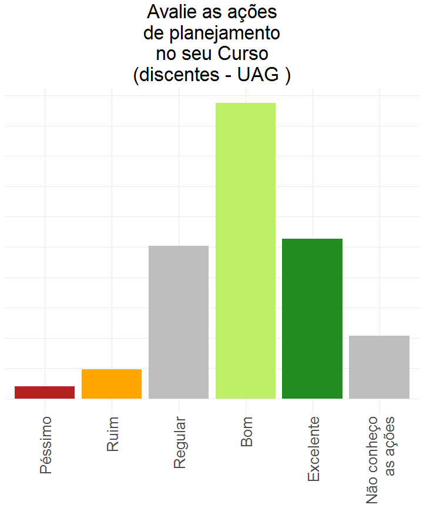

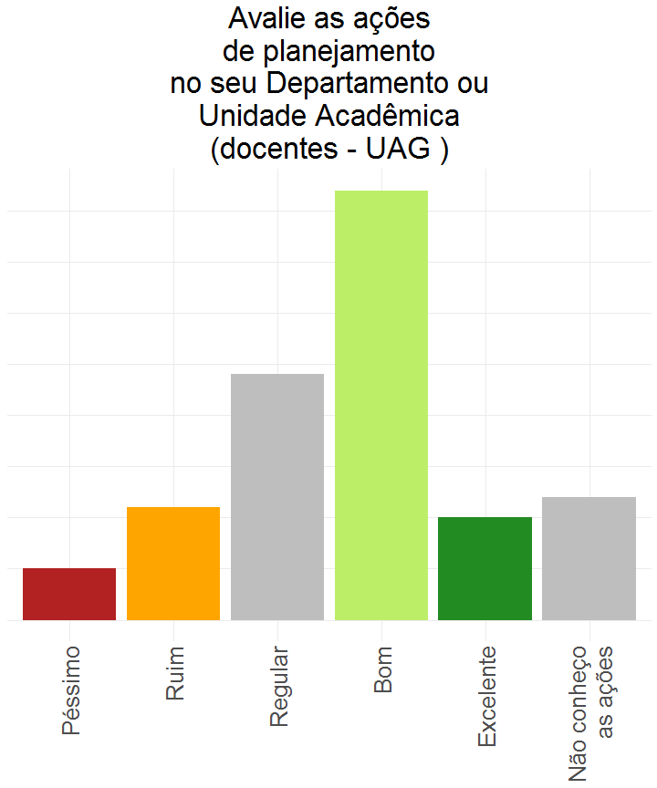

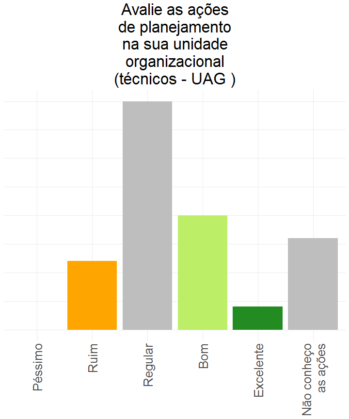

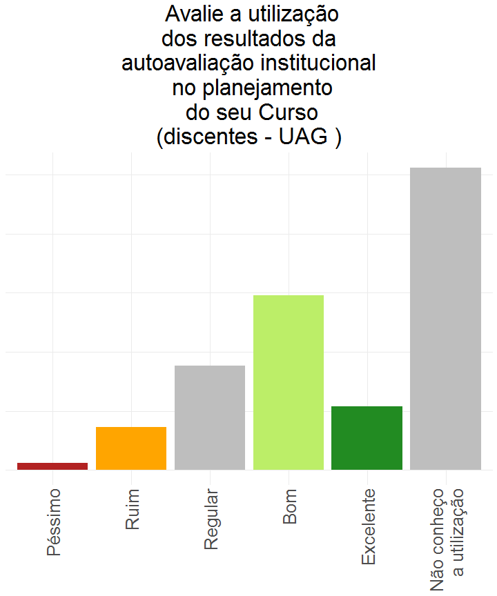

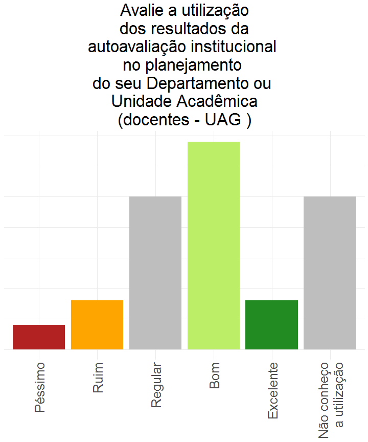

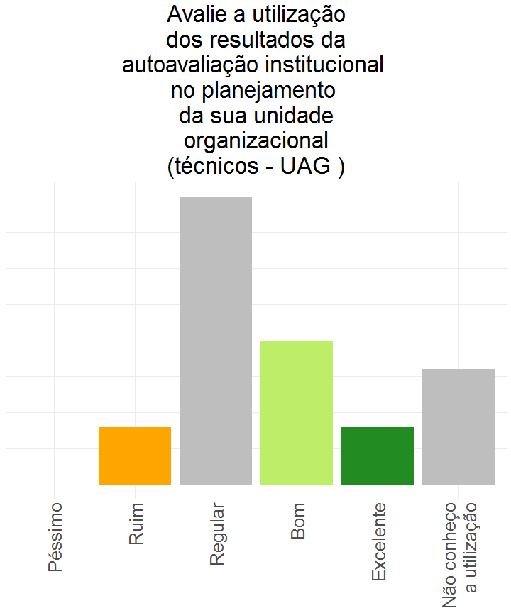

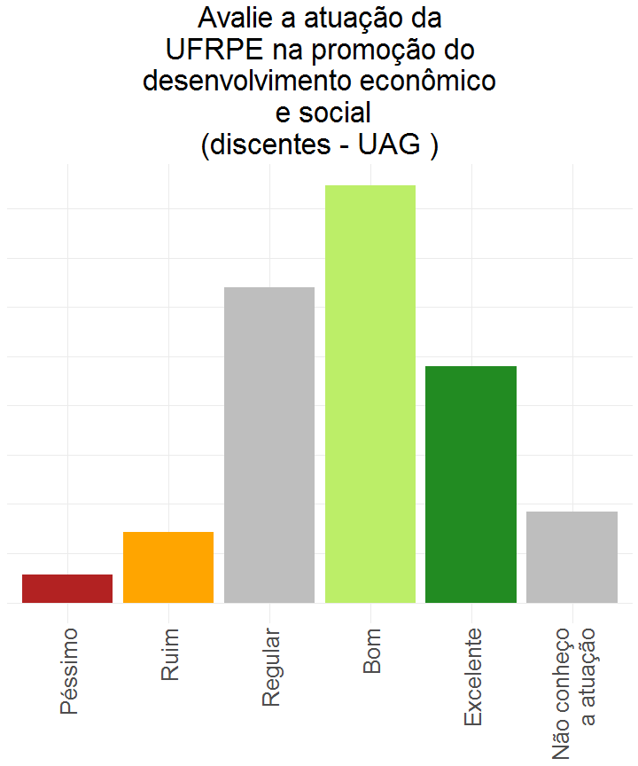

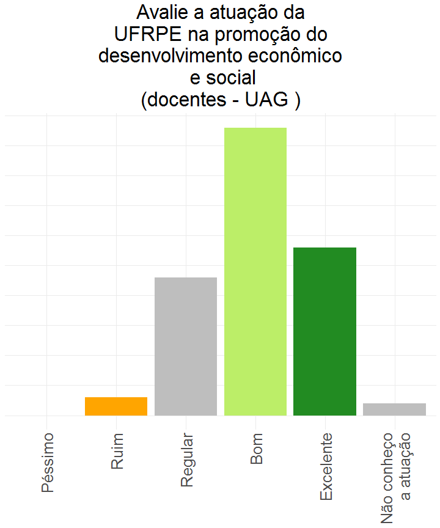

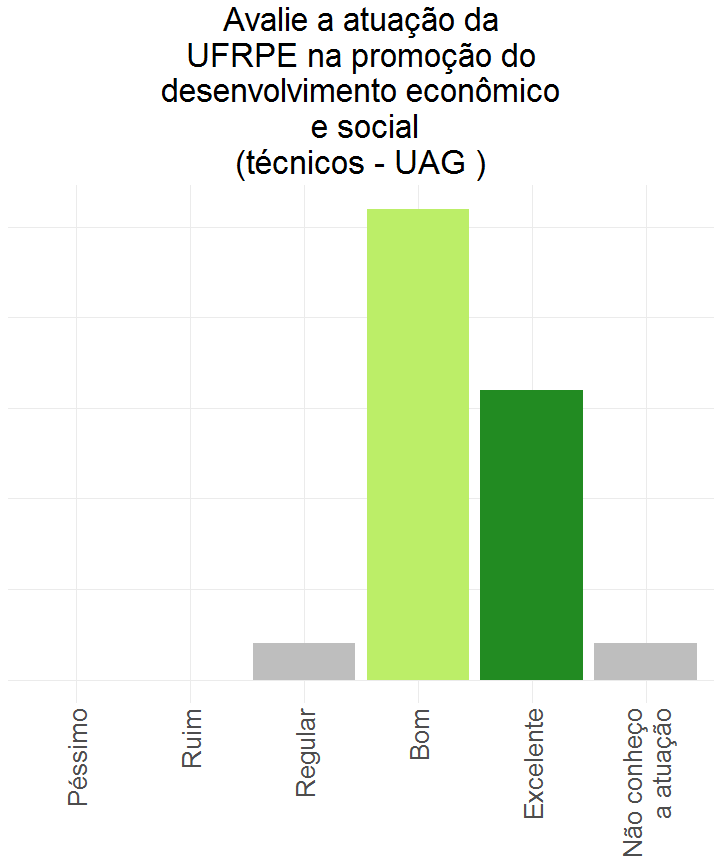

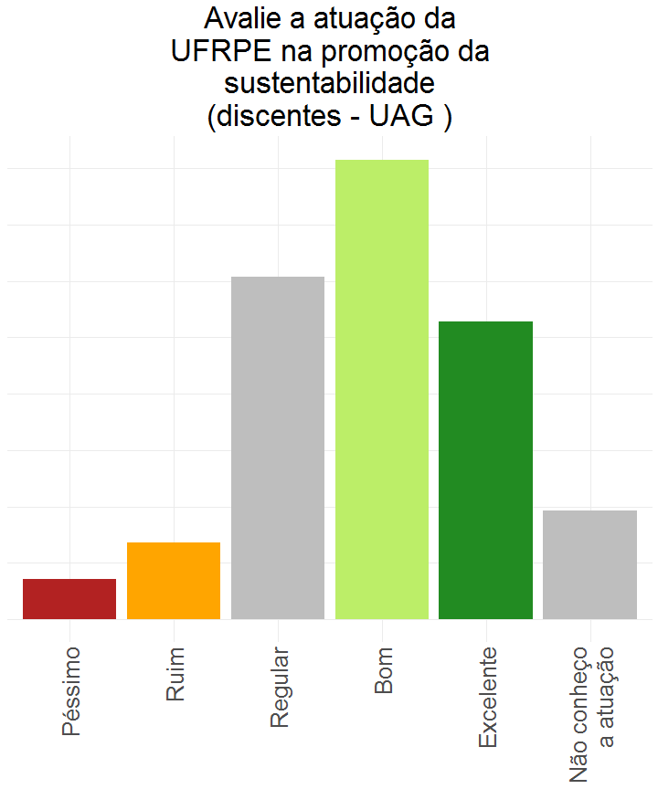

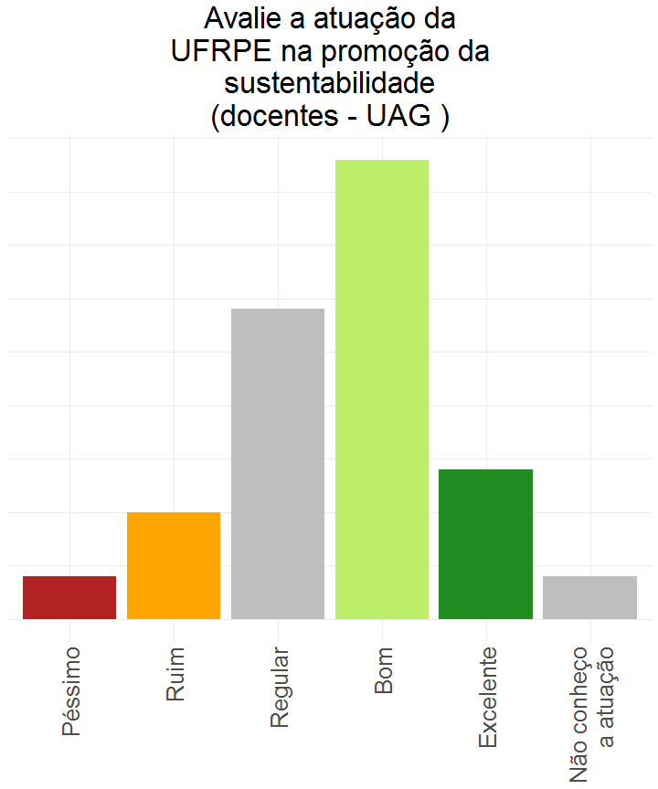

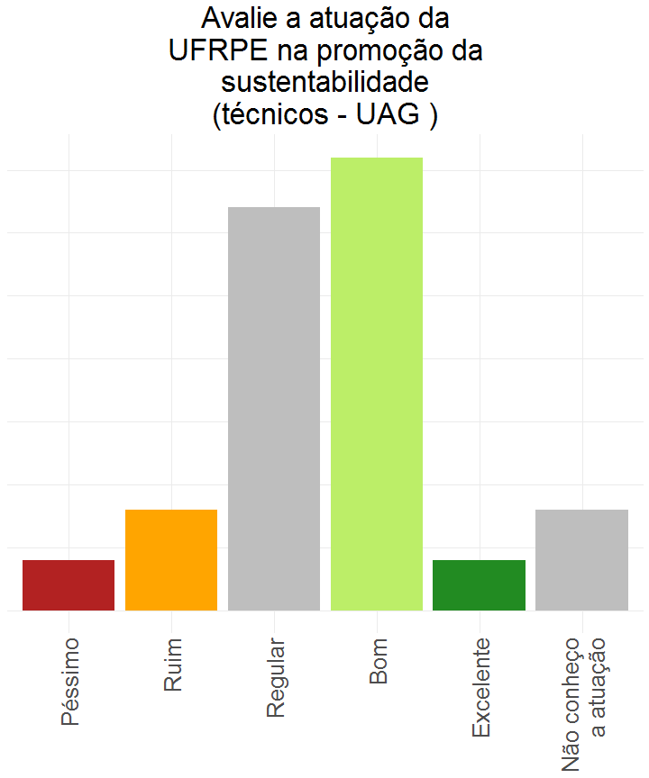

[6 more figures not shown]

# 3 DESTAQUES - PLANEJAMENTO E AVALIAÇÃO INSTITUCIONAL

Esta seção apresenta os resultados com maiores e menores médias numéricas referentes à avaliação do Planejamento e da Avaliação Institucional da UFRPE, conforme respondido pelos integrantes da Unidade Acadêmica de Garanhuns (UAG).

A seguir são apresentados os resultados classificados por segmento: discentes, docentes e técnicos.

## 3.1 Discentes (UAG)

Durante o período de avaliação esta unidade contava com 1587 **discentes** aptos a participar da avaliação, dos quais 294 (18.53%) responderam ao questionário. Do total das respostas referentes a Planejamento e Avaliação da instituição, 1.53% foram “péssimo”, 3.97% foram “ruim”, 15.99% foram “regular”, 36.05% foram “bom”, 17.12% foram “excelente”, e 25.34% foram outras opções de resposta.

### 3.1.1 Maiores médias:

Lista das 3 perguntas com respostas mais positivas, de um total de 6 perguntas, com base na média ponderada das respostas dos discentes desta unidade acadêmica.

| Item | Média |
| --- | --- |
| Avalie o acesso a este questionário de autoavaliação da UFRPE | 7.9 |
| Avalie as ações de planejamento no seu curso | 7.2 |
| Avalie o acesso aos relatórios de autoavaliação da UFRPE | 7.1 |

### 3.1.2 Menores médias:

Lista das 3 perguntas com respostas mais negativas, de um total de 6 perguntas, com base na média ponderada das respostas dos discentes desta unidade.

| Item | Média |
| --- | --- |
| Avalie a visibilidade da Comissão Própria de Avaliação (CPA) nas Mídias Sociais (Facebook e Instagram) | 6.2 |
| Avalie a utilização dos resultados da autoavaliação institucional no planejamento do seu Curso | 6.6 |
| Avalie o Projeto de Autoavaliação Institucional adotado pela Comissão Própria de Avaliação (CPA) | 7.0 |

## 3.2 Docentes (UAG)

Durante o período de avaliação esta unidade contava com 182 **docentes** aptos a participar da avaliação, dos quais 104 (57.14%) responderam ao questionário. Do total das respostas referentes a Planejamento e Avaliação da instituição, 1.92% foram “péssimo”, 6.73% foram “ruim”, 19.39% foram “regular”, 38.94% foram “bom”, 15.87% foram “excelente”, e 17.15% foram outras opções de resposta.

### 3.2.1 Maiores médias:

Lista das 3 perguntas com respostas mais positivas, de um total de 6 perguntas, com base na média ponderada das respostas dos docentes desta unidade acadêmica.

| Item | Média |
| --- | --- |
| Avalie o acesso a este questionário de autoavaliação da UFRPE. | 8.1 |
| Avalie o acesso aos relatórios de autoavaliação da UFRPE | 7.1 |
| Avalie o Projeto de Autoavaliação Institucional adotado pela Comissão Própria de Avaliação (CPA) | 7.1 |

### 3.2.2 Menores médias:

Lista das 3 perguntas com respostas mais negativas, de um total de 6 perguntas, com base na média ponderada das respostas dos docentes desta unidade acadêmica.

| Item | Média |
| --- | --- |
| Avalie a visibilidade da Comissão Própria de Avaliação (CPA) nas Mídias Sociais (Facebook e Instagram) | 5.8 |
| Avalie a utilização dos resultados da autoavaliação institucional no planejamento do seu Departamento ou Unidade Acadêmica | 6.1 |
| Avalie as ações de planejamento no seu Departamento ou Unidade Acadêmica | 6.1 |

## 3.3 Técnicos (UAG)

Durante o período de avaliação esta unidade contava com 87 **técnicos** aptos a participar da avaliação, dos quais 23 (26.44%) responderam ao questionário. Do total das respostas referentes a Planejamento e Avaliação da instituição, 0% foram “péssimo”, 4.35% foram “ruim”, 21.74% foram “regular”, 39.86% foram “bom”, 23.91% foram “excelente”, e 10.14% foram outras opções de resposta.

### 3.3.1 Maiores médias:

Lista das 3 perguntas com respostas mais positivas, de um total de 6 perguntas, com base na média ponderada das respostas dos técnicos desta unidade acadêmica.

| Item | Média |
| --- | --- |
| Avalie o acesso aos relatórios de autoavaliação da UFRPE | 8.6 |
| Avalie o acesso a este questionário de autoavaliação da UFRPE no site da Comissão Própria de Avaliaação (CPA) | 8.5 |
| Avalie o Projeto de Autoavaliação Institucional adotado pela Comissão Própria de Avaliação (CPA) | 8.0 |

### 3.3.2 Menores médias:

Lista das 3 perguntas com respostas mais negativas, de um total de 6 perguntas, com base na média ponderada das respostas dos técnicos desta unidade acadêmica.

| Item | Média |
| --- | --- |
| Avalie as ações de planejamento na sua unidade organizacional | 5.5 |
| Avalie a utilização dos resultados da autoavaliação institucional no planejamento de sua unidade organizacional | 5.9 |
| Avalie a visibilidade da Comissão Própria de Avaliação (CPA) nas Mídias Sociais (Facebook e Instagram) | 7.0 |

# 4 DESTAQUES - DESENVOLVIMENTO INSTITUCIONAL

Esta seção apresenta os resultados com maiores e menores médias numéricas referentes à avaliação do Desenvolvimento Institucional da UFRPE, conforme respondido pelos integrantes da Unidade Acadêmica de Garanhuns (UAG).

A seguir são apresentados os resultados classificados por segmento: discentes, docentes e técnicos.

## 4.1 Discentes (UAG)

Durante o período de avaliação esta unidade contava com 1587 **discentes** aptos a participar da avaliação, dos quais 294 (18.53%) responderam ao questionário. Do total das respostas referentes ao desenvolvimento institucional, 2.44% foram “péssimo”, 4.51% foram “ruim”, 21.06% foram “regular”, 31.32% foram “bom”, 16.76% foram “excelente”, e 23.9% foram outras opções de resposta.

### 4.1.1 Maiores médias:

Lista das 3 perguntas com respostas mais positivas, de um total de 11 perguntas, com base na média ponderada das respostas dos discentes desta unidade acadêmica.

| Item | Média |
| --- | --- |
| Avalie a atuação da UFRPE na promoção da igualdade étnico-racial | 7.5 |
| Avalie a atuação da UFRPE na promoção dos Direitos Humanos | 7.3 |
| Avalie a atuação da UFRPE na valorização da diversidade | 7.3 |

### 4.1.2 Menores médias:

Lista das 3 perguntas com respostas mais negativas, de um total de 11 perguntas, com base na média ponderada das respostas dos discentes desta unidade acadêmica.

| Item | Média |
| --- | --- |
| Avalie a atuação da UFRPE na promoção da produção artística | 6.0 |
| Avalie o seu conhecimento sobre o Plano de Desenvolvimento Institucional | 6.0 |
| Avalie seu conhecimento sobre o Plano de Gestão de Logística Sustentável (PLS) da UFRPE | 6.2 |

## 4.2 Docentes (UAG)

Durante o período de avaliação esta unidade contava com 182 **docentes** aptos a participar da avaliação, dos quais 104 (57.14%) responderam ao questionário. Do total das respostas referentes ao desenvolvimento institucional, 1.92% foram “péssimo”, 5.86% foram “ruim”, 22.64% foram “regular”, 39.16% foram “bom”, 13.46% foram “excelente”, e 16.96% foram outras opções de resposta.

### 4.2.1 Maiores médias:

Lista das 3 perguntas com respostas mais positivas, de um total de 11 perguntas, com base na média ponderada das respostas dos docentes desta unidade acadêmica.

| Item | Média |
| --- | --- |
| Avalie a atuação da UFRPE na promoção da igualdade étnico-racial | 7.8 |
| Avalie a atuação da UFRPE na valorização da diversidade | 7.6 |
| Avalie a atuação da UFRPE na promoção do desenvolvimento econômico e social | 7.5 |

### 4.2.2 Menores médias:

Lista das 3 perguntas com respostas mais negativas, de um total de 11 perguntas, com base na média ponderada das respostas dos docentes desta unidade acadêmica.

| Item | Média |
| --- | --- |
| Avalie a atuação da UFRPE na promoção da produção artística | 5.8 |
| Avalie a atuação da UFRPE na gestão de patrimônio cultural | 5.9 |
| Avalie o seu conhecimento sobre o Plano de Desenvolvimento Institucional (PDI) | 5.9 |

## 4.3 Técnicos (UAG)

Durante o período de avaliação esta unidade contava com 87 **técnicos** aptos a participar da avaliação, dos quais 23 (26.44%) responderam ao questionário. Do total das respostas referentes ao desenvolvimento institucional, 0.4% foram “péssimo”, 5.14% foram “ruim”, 22.53% foram “regular”, 45.45% foram “bom”, 17.39% foram “excelente”, e 9.09% foram outras opções de resposta.

### 4.3.1 Maiores médias:

Lista das 3 perguntas com respostas mais positivas, de um total de 11 perguntas, com base na média ponderada das respostas dos técnicos desta unidade acadêmica.

| Item | Média |
| --- | --- |
| Avalie a atuação da UFRPE na valorização da diversidade | 8.4 |
| Avalie a atuação da UFRPE na promoção do desenvolvimento econômico e social | 8.3 |
| Avalie a atuação da UFRPE na promoção da igualdade étnico-racial | 8.1 |

### 4.3.2 Menores médias:

Lista das 3 perguntas com respostas mais negativas, de um total de 11 perguntas, com base na média ponderada das respostas dos técnicos desta unidade acadêmica.

| Item | Média |
| --- | --- |
| Avalie a atuação da UFRPE na promoção da sustentabilidade | 5.8 |
| Avalie o seu conhecimento sobre o Plano de Desenvolvimento Institucional (PDI) | 6.0 |
| Avalie a atuação da UFRPE na promoção da produção artística | 6.1 |

# 5 RESULTADOS COMPLETOS

Esta seção apresenta as tabelas com as respostas a todas as perguntas do questionário de avaliação UFRPE 2019, conforme respondido pelos integrantes desta unidade, classificadas por segmento.

## 5.1 Planejamento e Avaliação Institucional

### 5.1.1 Discentes (UAG)

Resultados da avaliação de **Planejamento e Avaliação Institucional** da UFRPE, conforme respondido pelos discentes desta unidade acadêmica.

| Média | Item | Péssimo (0) | Ruim (2.5) | Regular (5) | Bom (7.5) | Excelente (10) | OOR* |
| --- | --- | --- | --- | --- | --- | --- | --- |
| 7.9 | Avalie o acesso a este questionário de autoavaliação da UFRPE | 3 | 6 | 27 | 159 | 99 | 0 |
| 7.2 | Avalie as ações de planejamento no seu curso | 5 | 12 | 63 | 122 | 66 | 26 |
| 7.1 | Avalie o acesso aos relatórios de autoavaliação da UFRPE | 2 | 12 | 60 | 120 | 49 | 51 |
| 7.0 | Avalie o Projeto de Autoavaliação Institucional adotado pela Comissão Própria de Avaliação (CPA) | 4 | 7 | 48 | 97 | 38 | 100 |
| 6.6 | Avalie a utilização dos resultados da autoavaliação institucional no planejamento do seu Curso | 3 | 18 | 44 | 74 | 27 | 128 |
| 6.2 | Avalie a visibilidade da Comissão Própria de Avaliação (CPA) nas Mídias Sociais (Facebook e Instagram) | 10 | 15 | 40 | 64 | 23 | 142 |

*OOR: Outras opções de resposta

### 5.1.2 Docentes (UAG)

Resultados da avaliação de Planejamento e Avaliação Institucional da UFRPE, conforme respondido pelos docentes desta unidade acadêmica.

| Média | Item | Péssimo (0) | Ruim (2.5) | Regular (5) | Bom (7.5) | Excelente (10) | OOR* |
| --- | --- | --- | --- | --- | --- | --- | --- |
| 8.1 | Avalie o acesso a este questionário de autoavaliação da UFRPE. | 0 | 3 | 16 | 37 | 48 | 0 |
| 7.1 | Avalie o acesso aos relatórios de autoavaliação da UFRPE | 0 | 6 | 19 | 53 | 16 | 10 |
| 7.1 | Avalie o Projeto de Autoavaliação Institucional adotado pela Comissão Própria de Avaliação (CPA) | 2 | 3 | 13 | 53 | 12 | 21 |
| 6.1 | Avalie a utilização dos resultados da autoavaliação institucional no planejamento do seu Departamento ou Unidade Acadêmica | 4 | 8 | 25 | 34 | 8 | 25 |
| 6.1 | Avalie as ações de planejamento no seu Departamento ou Unidade Acadêmica | 5 | 11 | 24 | 42 | 10 | 12 |
| 5.8 | Avalie a visibilidade da Comissão Própria de Avaliação (CPA) nas Mídias Sociais (Facebook e Instagram) | 1 | 11 | 24 | 24 | 5 | 39 |

*OOR: Outras opções de resposta

### 5.1.3 Técnicos (UAG)

Resultados da avaliação de Planejamento e Avaliação Institucional da UFRPE, conforme respondido pelos técnicos desta unidade acadêmica.

| Média | Item | Péssimo (0) | Ruim (2.5) | Regular (5) | Bom (7.5) | Excelente (10) | OOR* |
| --- | --- | --- | --- | --- | --- | --- | --- |
| 8.6 | Avalie o acesso aos relatórios de autoavaliação da UFRPE | 0 | 0 | 1 | 10 | 10 | 2 |
| 8.5 | Avalie o acesso a este questionário de autoavaliação da UFRPE no site da Comissão Própria de Avaliaação (CPA) | 0 | 0 | 1 | 12 | 10 | 0 |
| 8.0 | Avalie o Projeto de Autoavaliação Institucional adotado pela Comissão Própria de Avaliação (CPA) | 0 | 0 | 3 | 11 | 7 | 2 |
| 7.0 | Avalie a visibilidade da Comissão Própria de Avaliação (CPA) nas Mídias Sociais (Facebook e Instagram) | 0 | 1 | 5 | 12 | 3 | 2 |
| 5.9 | Avalie a utilização dos resultados da autoavaliação institucional no planejamento de sua unidade organizacional | 0 | 2 | 10 | 5 | 2 | 4 |
| 5.5 | Avalie as ações de planejamento na sua unidade organizacional | 0 | 3 | 10 | 5 | 1 | 4 |

*OOR: Outras opções de resposta

## 5.2 Desenvolvimento Institucional

### 5.2.1 Discentes (UAG)

Resultados da avaliação do **Desenvolvimento Institucional** da UFRPE, conforme respondido pelos discentes desta unidade acadêmica.

| Média | Item | Péssimo (0) | Ruim (2.5) | Regular (5) | Bom (7.5) | Excelente (10) | OOR* |
| --- | --- | --- | --- | --- | --- | --- | --- |
| 7.5 | Avalie a atuação da UFRPE na promoção da igualdade étnico-racial | 4 | 9 | 52 | 121 | 86 | 22 |
| 7.3 | Avalie a atuação da UFRPE na promoção dos Direitos Humanos | 6 | 8 | 65 | 112 | 78 | 25 |
| 7.3 | Avalie a atuação da UFRPE na valorização da diversidade | 8 | 11 | 60 | 115 | 82 | 18 |
| 7.1 | Avalie o Plano de Desenvolvimento Institucional (PDI) da UFRPE como instrumento de gestão (Planejamento, execução e avaliação) | 2 | 5 | 35 | 93 | 24 | 135 |
| 6.8 | Avalie a atuação da UFRPE na promoção da sustentabilidade | 9 | 17 | 76 | 102 | 66 | 24 |
| 6.8 | Avalie a atuação da UFRPE na promoção do desenvolvimento econômico e social | 7 | 18 | 80 | 106 | 60 | 23 |
| 6.8 | Avalie o alinhamento das diretrizes e objetivos estratégicos do Plano de Desenvolvimento Institucional (PDI) com as ações executadas na UFRPE | 5 | 3 | 48 | 73 | 24 | 141 |
| 6.5 | Avalie a atuação da UFRPE na gestão do patrimônio cultural | 9 | 19 | 79 | 93 | 49 | 45 |
| 6.2 | Avalie seu conhecimento sobre o Plano de Gestão de Logística Sustentável (PLS) da UFRPE | 3 | 13 | 46 | 48 | 16 | 168 |
| 6.0 | Avalie a atuação da UFRPE na promoção da produção artística | 21 | 21 | 78 | 91 | 35 | 48 |
| 6.0 | Avalie o seu conhecimento sobre o Plano de Desenvolvimento Institucional | 5 | 22 | 62 | 59 | 22 | 124 |

*OOR: Outras opções de resposta

### 5.2.2 Docentes (UAG)

Resultados da avaliação do Desenvolvimento Institucional da UFRPE, conforme respondido pelos docentes desta unidade acadêmica.

| Média | Item | Péssimo (0) | Ruim (2.5) | Regular (5) | Bom (7.5) | Excelente (10) | OOR* |
| --- | --- | --- | --- | --- | --- | --- | --- |
| 7.8 | Avalie a atuação da UFRPE na promoção da igualdade étnico-racial | 1 | 3 | 11 | 46 | 31 | 12 |
| 7.6 | Avalie a atuação da UFRPE na valorização da diversidade | 1 | 3 | 16 | 46 | 27 | 11 |
| 7.5 | Avalie a atuação da UFRPE na promoção do desenvolvimento econômico e social | 0 | 3 | 23 | 48 | 28 | 2 |
| 7.2 | Avalie a atuação da UFRPE na promoção dos Direitos Humanos | 2 | 3 | 16 | 48 | 19 | 16 |
| 6.8 | Avalie o PDI da UFRPE como instrumento de gestão ( Planejamento, execução e avaliação) | 1 | 2 | 23 | 53 | 5 | 20 |
| 6.4 | Avalie o alinhamento das diretrizes e objetivos estratégicos do PDI com as as ações executadas na UFRPE | 0 | 7 | 25 | 45 | 3 | 24 |
| 6.3 | Avalie a atuação da UFRPE na promoção da sustentabilidade | 4 | 10 | 29 | 43 | 14 | 4 |
| 6.1 | Avalie seu conhecimento sobre o Plano de Gestão de Logística Sustentável (PLS) da UFRPE | 0 | 7 | 24 | 21 | 5 | 47 |
| 5.9 | Avalie a atuação da UFRPE na gestão de patrimônio cultural | 7 | 9 | 24 | 30 | 11 | 23 |
| 5.9 | Avalie o seu conhecimento sobre o Plano de Desenvolvimento Institucional (PDI) | 0 | 8 | 41 | 33 | 3 | 19 |
| 5.8 | Avalie a atuação da UFRPE na promoção da produção artística | 6 | 12 | 27 | 35 | 8 | 16 |

*OOR: Outras opções de resposta

### 5.2.3 Técnicos (UAG)

Resultados da avaliação do Desenvolvimento Institucional da UFRPE, conforme respondido pelos técnicos desta unidade acadêmica.

| Média | Item | Péssimo (0) | Ruim (2.5) | Regular (5) | Bom (7.5) | Excelente (10) | OOR* |
| --- | --- | --- | --- | --- | --- | --- | --- |
| 8.4 | Avalie a atuação da UFRPE na valorização da diversidade | 0 | 0 | 1 | 12 | 9 | 1 |
| 8.3 | Avalie a atuação da UFRPE na promoção do desenvolvimento econômico e social | 0 | 0 | 1 | 13 | 8 | 1 |
| 8.1 | Avalie a atuação da UFRPE na promoção da igualdade étnico-racial | 0 | 0 | 2 | 12 | 7 | 2 |
| 7.6 | Avalie a atuação da UFRPE na promoção dos Direitos Humanos | 0 | 0 | 4 | 12 | 5 | 2 |
| 7.6 | Avalie o Plano de Desenvolvimento Institucional (PDI) da UFRPE como instrumento de gestão ( Planejamento, execução e avaliação) | 0 | 0 | 3 | 14 | 4 | 2 |
| 6.7 | Avalie o alinhamento das diretrizes e objetivos estratégicos do Plano de Desenvolvimento Institucional (PDI) com as ações executadas na UFRPE | 0 | 0 | 9 | 10 | 2 | 2 |
| 6.4 | Avalie a atuação da UFRPE na gestão do patrimônio cultural | 0 | 2 | 7 | 10 | 2 | 2 |
| 6.1 | Avalie a atuação da UFRPE na promoção da produção artística | 0 | 4 | 7 | 8 | 3 | 1 |
| 6.1 | Avalie seu conhecimento sobre o Plano de Gestão de Logística Sustentável (PLS) da UFRPE | 0 | 2 | 6 | 7 | 1 | 7 |
| 6.0 | Avalie o seu conhecimento sobre o Plano de Desenvolvimento Institucional (PDI) | 0 | 3 | 9 | 8 | 2 | 1 |
| 5.8 | Avalie a atuação da UFRPE na promoção da sustentabilidade | 1 | 2 | 8 | 9 | 1 | 2 |

*OOR: Outras opções de resposta